# A Few Things You Can Do with the ‘likert’ Package

Michelle Trexler Welker

August 10, 2021

# Introduction

If you’ve ever taken a customer satisfaction survey, you are probably familiar with a Likert scale. A Likert scale survey question asks you to rank your response on a scale (usually with five to seven options). For example, you may be asked if your shopping experience was “Excellent, Good, Neutral, Poor, or Terrible.” Other common options are “Strongly Agree” to “Strongly Disagree” and “Very Satisfied” to “Very Dissatisfied.”

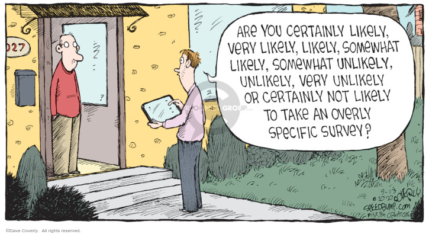

*This image is copyright protected. The copyright owner reserves all rights.*

In contrast with a simple “yes/no” answer, the Likert scale allows the respondent to share the strength of their opinion, or no opinion at all (McLeod, 2019). It is used in nearly every line of business and can measure customer satisfaction, employee engagement, or the success of marketing campaigns or other events. While Likert scale surveys are relatively easy to administer, take, and tabulate, it’s not as easy to represent such survey results graphically. The “likert” package for r, developed by Jason Bryer and Kim Speerschneider, allows users to quickly visualize Likert survey results in several different formats.

# likert Package Tutorial

In this tutorial, we will first learn how to wrangle your data so it can be used with the likert package. We will then use likert to generate the basic chart types. And finally, we’ll learn a few ways you can customize your charts

## Loading the Packages and the Data

First, we’ll install and load the likert package. We’ll also load dplyr.

```r
install.packages('likert', repos = "http://cran.us.r-project.org")
library(likert)
library(dplyr)
```

For this demonstration, we have the (made up) results of a patient satisfaction survey for a (fictional) medical practice. We’ll read the data in as follows:

```r
dat <- read.csv(file = 'https://docs.google.com/spreadsheets/d/e/2PACX-1vTEo-xFR3lDB-7w-6kLeTPgXyvv8fXGAT6MB3uDrKFP_igFiPCUjitdgBFIRBmuMNht2GwJdJhZPOtG/pub?output=csv')
```

## Data Preparation

Let’s use `str()` to check out the structure of the file:

```r
str(dat)
```

```
## 'data.frame':    100 obs. of  10 variables:
##  $ ID                                                                          : int  1 2 3 4 5 6 7 8 9 10 ...
##  $ Timestamp                                                                   : chr  "8/9/2021 22:17:59" "8/9/2021 22:18:20" "8/9/2021 22:18:38" "8/9/2021 22:18:56" ...
##  $ The.doctor.took.the.time.to.listen.to.my.concerns.and.answer.my.questions   : int  5 5 4 5 3 1 5 5 NA 3 ...
##  $ The.doctor.clearly.explained.how.to.manage.my.condition                     : int  5 4 4 5 3 1 5 5 NA NA ...
##  $ The.doctor.talked.to.me.about.how.to.stay.healthy                           : int  2 3 4 5 3 1 4 3 NA NA ...
##  $ The.doctor.is.knowledgeable.and.competent.with.regard.to.my.medical.concerns: int  4 4 4 5 5 4 5 5 4 4 ...
##  $ The.doctor.was.respectful.to.me.and.to.others.in.the.office                 : int  5 3 4 5 4 2 3 5 4 3 ...
##  $ Which.doctor.did.you.see.                                                   : chr  "Elena Garcia" "Elena Garcia" "Elena Garcia" "Elena Garcia" ...
##  $ Your.age                                                                    : chr  "31-45" "18-30" "18-30" "65+" ...
##  $ Your.gender                                                                 : chr  "Female" "Female" "Male" "Female" ...
```

### Nice column names

There are a few issues we need to clean up in this data before we go any further. First of all, we’ll remove the periods from the column names so that they will display nicely on the final chart. We’ll use the `chartr()`, or character translation function to replace the periods with spaces.

```r
names(dat) <- chartr("."," ",names(dat))
```

### Recast numbers as factors

In looking at the variables, we can see the Likert-scale questions are in columns 3-7. While they are listed as integers, they really represent categories rather than numeric values. In addition, the likert package requires that the variables be factors of equal length, so we will recast those columns as factors with `mutate_at`.

```r
dat.fac <-dat %>%
  mutate_at(3:10, as.factor)
```

You may notice that we also recast the final three columns as factors. That is because they also contain categorical data: which doctor was seen, age group, and gender.

### Create levels for factors

In the survey, the patients were asked to express their sentiment as one of five options ranging from Strongly Disagree (1) to Strongly Agree (5). However, in the data, only the number (1-5) was saved. We want the words to show up on our charts so we will use the `levels` function to indicate what level each of the numbers represents.

```r
levels(dat.fac$`The doctor took the time to listen to my concerns and answer my questions`) <-
  c("Strongly Disagree", "Disagree", "Neutral", "Agree", "Strongly Agree")
levels(dat.fac$`The doctor clearly explained how to manage my condition`) <-
  c("Strongly Disagree", "Disagree", "Neutral", "Agree", "Strongly Agree")
levels(dat.fac$`The doctor talked to me about how to stay healthy`) <-
  c("Strongly Disagree", "Disagree", "Neutral", "Agree", "Strongly Agree")
levels(dat.fac$`The doctor is knowledgeable and competent with regard to my medical concerns`) <-
  c("Strongly Disagree", "Disagree", "Neutral", "Agree", "Strongly Agree")
levels(dat.fac$`The doctor was respectful to me and to others in the office`) <-
  c("Strongly Disagree", "Disagree", "Neutral", "Agree", "Strongly Agree")
```

Then let’s check out the structure again to see if it reflects all the changes we made.

```r
str(dat.fac)
```

```
## 'data.frame':    100 obs. of  10 variables:
##  $ ID                                                                          : int  1 2 3 4 5 6 7 8 9 10 ...
##  $ Timestamp                                                                   : chr  "8/9/2021 22:17:59" "8/9/2021 22:18:20" "8/9/2021 22:18:38" "8/9/2021 22:18:56" ...
##  $ The doctor took the time to listen to my concerns and answer my questions   : Factor w/ 5 levels "Strongly Disagree",..: 5 5 4 5 3 1 5 5 NA 3 ...
##  $ The doctor clearly explained how to manage my condition                     : Factor w/ 5 levels "Strongly Disagree",..: 5 4 4 5 3 1 5 5 NA NA ...
##  $ The doctor talked to me about how to stay healthy                           : Factor w/ 5 levels "Strongly Disagree",..: 2 3 4 5 3 1 4 3 NA NA ...
##  $ The doctor is knowledgeable and competent with regard to my medical concerns: Factor w/ 5 levels "Strongly Disagree",..: 4 4 4 5 5 4 5 5 4 4 ...
##  $ The doctor was respectful to me and to others in the office                 : Factor w/ 5 levels "Strongly Disagree",..: 5 3 4 5 4 2 3 5 4 3 ...
##  $ Which doctor did you see                                                    : Factor w/ 3 levels "Charles Lee",..: 2 2 2 2 2 1 1 1 1 1 ...
##  $ Your age                                                                    : Factor w/ 5 levels "18-30","31-45",..: 2 1 1 4 3 3 2 3 1 3 ...
##  $ Your gender                                                                 : Factor w/ 3 levels "Female","Male",..: 1 1 2 1 1 2 1 2 1 2 ...
```

We can see that:  
* The column names have the periods removed,  
* Columns 3-10 are all classed as factors, and  
* Even though the Likert variables are still stored as numbers, they are recognized as representing levels of agreement.

This last point is even more clear if we take a look at rows 1-10 and see that they display the words instead of numbers:

```r
dat.fac[1:10,3:7]
```

|  | The doctor took the time to listen to my concerns and answer my questions | The doctor clearly explained how to manage my condition | The doctor talked to me about how to stay healthy | The doctor is knowledgeable and competent with regard to my medical concerns | The doctor was respectful to me and to others in the office |
| --- | --- | --- | --- | --- | --- |
| 1 | Strongly Agree | Strongly Agree | Disagree | Agree | Strongly Agree |
| 2 | Strongly Agree | Agree | Neutral | Agree | Neutral |
| 3 | Agree | Agree | Agree | Agree | Agree |
| 4 | Strongly Agree | Strongly Agree | Strongly Agree | Strongly Agree | Strongly Agree |
| 5 | Neutral | Neutral | Neutral | Strongly Agree | Agree |
| 6 | Strongly Disagree | Strongly Disagree | Strongly Disagree | Agree | Disagree |
| 7 | Strongly Agree | Strongly Agree | Agree | Strongly Agree | Neutral |
| 8 | Strongly Agree | Strongly Agree | Neutral | Strongly Agree | Strongly Agree |
| 9 | NA | NA | NA | Agree | Agree |
| 10 | Neutral | NA | NA | Agree | Neutral |

## Creating a likert Object

As mentioned before, the likert package requires a dataframe where all variables are factors of equal length. This means that we only want to read in the columns that contain Likert-scale data, which are columns 3-7 in this case. We will create a new object, `dat.lik`, by applying the `likert` function to columns 3-7 of dat.fac:

```r
dat.lik <- likert(dat.fac[,3:7])
dat.lik
```

```
##                                                                           Item
## 1    The doctor took the time to listen to my concerns and answer my questions
## 2                      The doctor clearly explained how to manage my condition
## 3                            The doctor talked to me about how to stay healthy
## 4 The doctor is knowledgeable and competent with regard to my medical concerns
## 5                  The doctor was respectful to me and to others in the office
##   Strongly Disagree  Disagree   Neutral    Agree Strongly Agree
## 1          2.083333  8.333333 14.583333 35.41667       39.58333
## 2          4.255319 10.638298 23.404255 25.53191       36.17021
## 3         19.512195  9.756098 28.048780 21.95122       20.73171
## 4          1.020408  2.040816  5.102041 44.89796       46.93878
## 5          1.020408  5.102041 20.408163 18.36735       55.10204
```

The cran-r documentation for this package tells us that the likert() function creates an object that is “likert class” (Bryer, J. and Speerschneider, K., 2016). We can use `summary()` to tell us a little bit more about this object:

```r
summary(dat.lik)
```

|  | Item | low | neutral | high | mean | sd |
| --- | --- | --- | --- | --- | --- | --- |
| 4 | The doctor is knowledgeable and competent with regard to my medical concerns | 3.061224 | 5.102041 | 91.83673 | 4.346939 | 0.7611987 |
| 1 | The doctor took the time to listen to my concerns and answer my questions | 10.416667 | 14.583333 | 75.00000 | 4.020833 | 1.0359757 |
| 5 | The doctor was respectful to me and to others in the office | 6.122449 | 20.408163 | 73.46939 | 4.214286 | 1.0077023 |
| 2 | The doctor clearly explained how to manage my condition | 14.893617 | 23.404255 | 61.70213 | 3.787234 | 1.1720063 |
| 3 | The doctor talked to me about how to stay healthy | 29.268293 | 28.048780 | 42.68293 | 3.146341 | 1.3888618 |

Because likert data is categorical, not numeric, the calculations of mean and standard deviation are not really meaningful, but are still interesting to look at.

## Basic Plots

And now that we have a likert object, we can apply the other functions from the package. Without further ado, let’s look at the four plots that come with the likert package, with their default options.

### Bar Plot

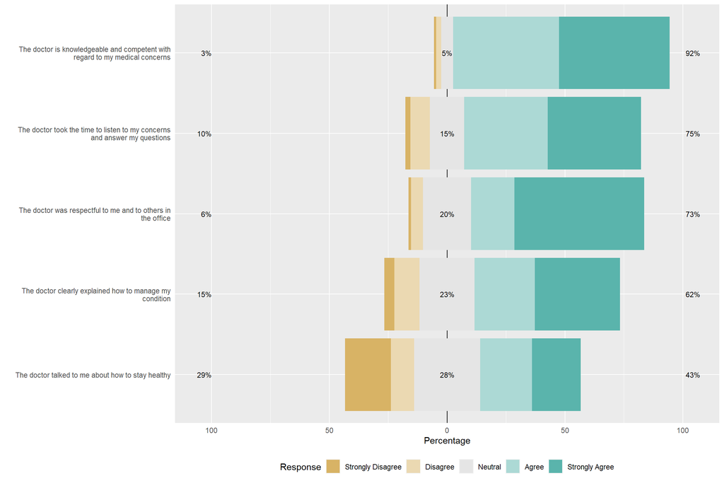

```r
likert.bar.plot(dat.lik)
```

### Density Plot

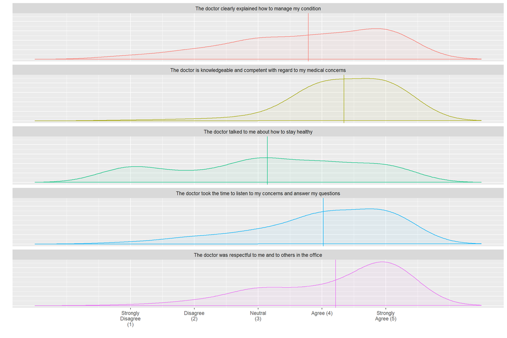

```r
likert.density.plot(dat.lik)
```

### Heatmap

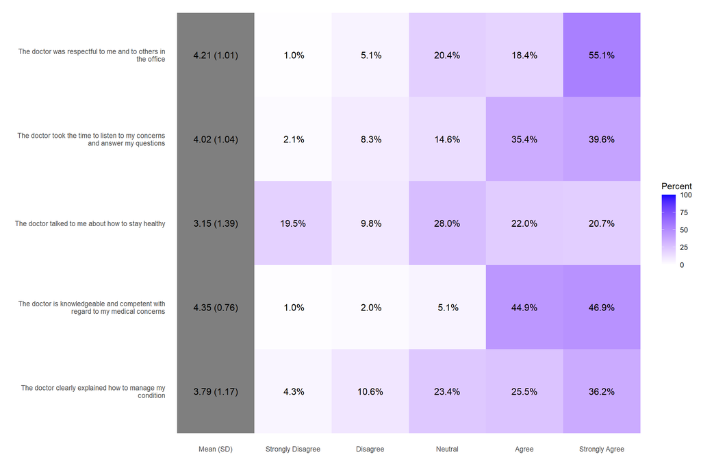

```r
likert.heat.plot(dat.lik)
```

### Histogram

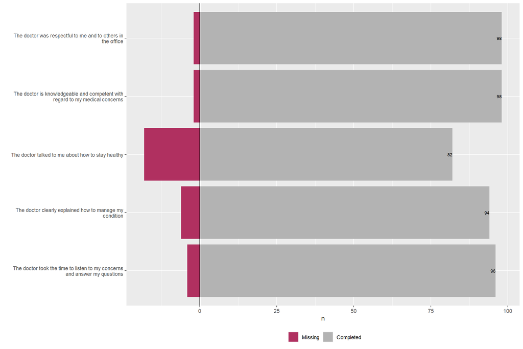

```r
likert.histogram.plot(dat.lik)
```

While not every chart is appropriate for every use, these four options provide a variety of ways to view and analyze the results of Likert-scale surveys.

## Options for Customization

While these default plots are a good start, there are many ways to customize charts as well. To see some of those options, just enter `likert.options`:

```r
likert.options
```

```
## function (low.color = "#D8B365", high.color = "#5AB4AC", neutral.color = "grey90",
##     neutral.color.ramp = "white", colors = NULL, plot.percent.low = TRUE,
##     plot.percent.high = TRUE, plot.percent.neutral = TRUE, plot.percents = FALSE,
##     text.size = 3, text.color = "black", centered = TRUE, include.center = TRUE,
##     ordered = TRUE, wrap = 50, wrap.grouping = 50, legend = "Response",
##     legend.position = "bottom", panel.arrange = "v", panel.strip.color = "#F0F0F0",
##     digits = 0, drop0trailing = FALSE, zero.print = TRUE, ...)
## {
##     opts <- list(low.color = low.color, high.color = high.color,
##         neutral.color = neutral.color, neutral.color.ramp = neutral.color.ramp,
##         colors = colors, plot.percent.low = plot.percent.low,
##         plot.percent.high = plot.percent.high, plot.percent.neutral = plot.percent.neutral,
##         plot.percents = plot.percents, text.size = text.size,
##         text.color = text.color, centered = centered, include.center = include.center,
##         ordered = ordered, wrap = wrap, wrap.grouping = wrap.grouping,
##         legend = legend, legend.position = legend.position, panel.arrange = panel.arrange,
##         panel.strip.color = panel.strip.color, digits = digits,
##         drop0trailing = drop0trailing, zero.print = zero.print)
##     return(opts)
## }
## <bytecode: 0x00000000162be980>
## <environment: namespace:likert>
```

Let’s try out a few of them.

### Colors

Personally, I’m not a fan of the default colors, so let’s change them to the maroon and gold of ASU:

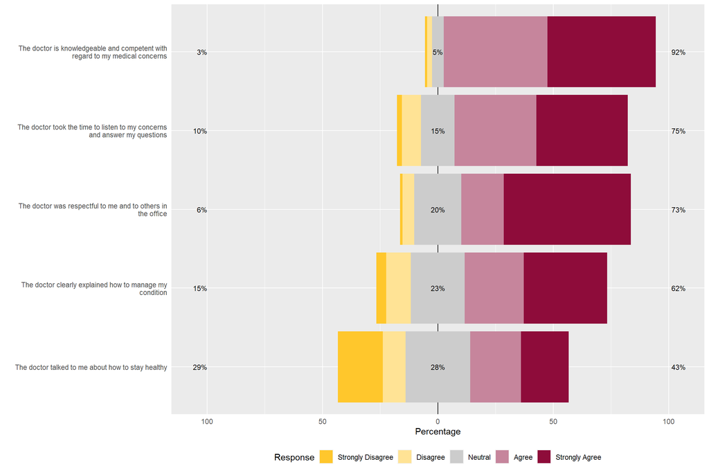

```r
likert.bar.plot(dat.lik,
                low.color = "#FFC72C",
                high.color = "#8E0C3A",
                neutral.color = "grey80")
```

### Centering, size

The default bar plot is centered on the middle option. But we can choose to have the data fill the width of the chart with `centered = FALSE`. I also added `wrap = 20` (to make the label column narrower and the chart wider) and set the `text.size = 5` to enlarge the percentage numbers.

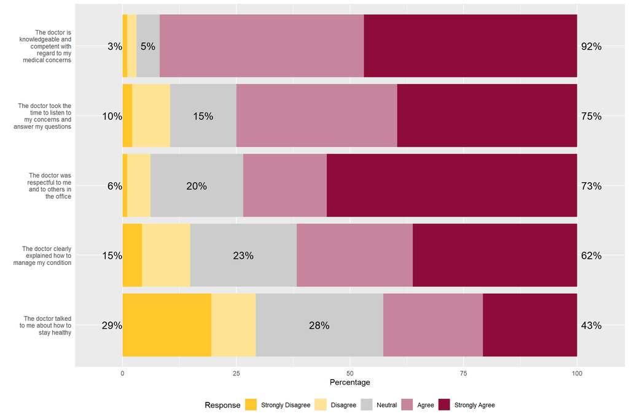

```r
likert.bar.plot(dat.lik,
                centered=FALSE,
                wrap = 20,
                text.size = 5,
                low.color = "#FFC72C",
                high.color = "#8E0C3A",
                neutral.color = "grey80")
```

*Sadly, I couldn’t find a way to enlarge the other fonts on the chart.*

### Alternative Density Plot

Just because it’s so pretty, we’ll finish with this “unfaceted” density plot. The default version plots each question separately, but setting `facet = FALSE` plots them all together for comparison. Is it useful? I’m not sure. But I find the colors soothing.

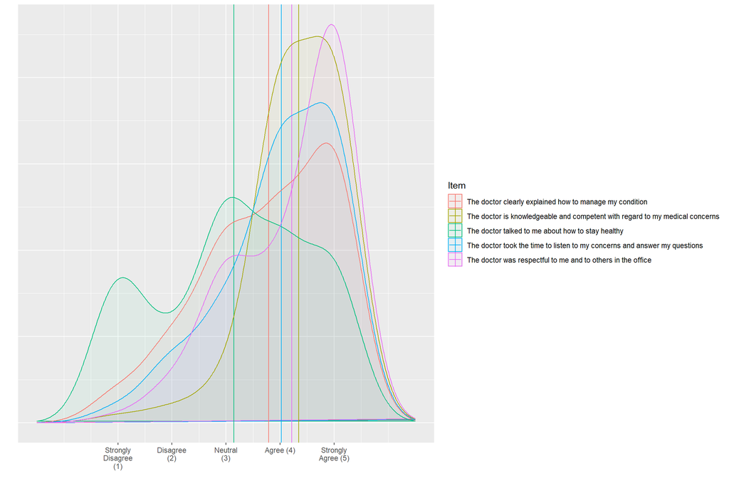

```r
likert.density.plot(dat.lik, facet = FALSE)
```

# Further Resources

To learn more about the likert package:

- [Jason Bryer’s likert package GitHub page](https://github.com/jbryer/likert)
- https://www.rdocumentation.org/packages/likert/versions/1.3.5

To learn more about the Likert scale:

- [Survey Monkey article about the Likert scale](https://www.surveymonkey.com/mp/likert-scale/)

# Works Cited

This code through references and cites the following sources:

- Bryer, J. and Speerschneider, K. (2016). Package ‘likert’. https://cran.r-project.org/web/packages/likert/likert.pdf
- Coverly, D. (2020, September 13). Speed Bump (comic strip). https://www.cartoonistgroup.com/cartoon/Speed+Bump/2020-09-13/184635
- McLeod, S. A. (2019, August 03). Likert scale. Simply Psychology. https://www.simplypsychology.org/likert-scale.html